# Lição Github Nº 6

Construindo gráficos com ggplot

Luis Fernando dos Santos de Brito

(06/09/2021)

## 1. Introdução

- *Nesse projeto vou criar seis tipos de gráficos para representar os dados dos dataset de uma forma simples de conpreeder os dados do dataset.*
- *O dataset dados_co2 foi escolhido, pois já tinha trabalhado com esse dataset então foi mais simples para enteder.*
- *O dataset notas_disciplina foi escolhido, pois o dataset parecia muito simples para entender é contém poucos dados.*

### 2. carregar o “tidyverse”

- carregar o tidyverse

```r
library(tidyverse)
```

### 3. lendo dados

```r
co2_tidy <- read.csv ("dados/co2_tidy.csv")

co2_tidy
```

| ano | mes | ppm |
| --- | --- | --- |
| 1959 | jan | 315.42 |
| 1959 | fev | 316.31 |
| 1959 | mar | 316.50 |
| 1959 | abr | 317.56 |
| 1959 | mai | 318.13 |
| 1959 | jun | 318.00 |
| 1959 | jul | 316.39 |
| 1959 | ago | 314.65 |
| 1959 | set | 313.68 |
| 1959 | out | 313.18 |

[output cut: 458 more lines]

```r
notas_tidy <- read.csv("dados/notas_tidy.csv")

notas_tidy
```

| Curso | ano | ppm |
| --- | --- | --- |
| Qui | X2010 | 2.9 |
| Qui | X2011 | 6.8 |
| Qui | X2012 | 6.2 |
| Qui | X2013 | 4.1 |
| Qui | X2014 | 5.6 |
| Qui | X2015 | 4.0 |
| Qui | X2016 | 6.0 |
| Qui | X2017 | 7.4 |
| Qui | X2018 | 6.0 |
| Qui | X2019 | 4.1 |

[output cut: 210 more lines]

### 1. Gráficos de Pontos:

#### 1º Camada *Dataset* (co2_tidy)

- carregando o conjunto do dataset co2_tidy

```r
co2_tidy
```

| ano | mes | ppm |
| --- | --- | --- |
| 1959 | jan | 315.42 |
| 1959 | fev | 316.31 |
| 1959 | mar | 316.50 |
| 1959 | abr | 317.56 |
| 1959 | mai | 318.13 |
| 1959 | jun | 318.00 |
| 1959 | jul | 316.39 |
| 1959 | ago | 314.65 |
| 1959 | set | 313.68 |
| 1959 | out | 313.18 |

[output cut: 458 more lines]

#### 2º Camada *group_by* (agrupamento de linha)

- Agrupando os dados da coluna ano.

```r
co2_tidy %>%
  group_by(ano)
```

| ano | mes | ppm |
| --- | --- | --- |
| 1959 | jan | 315.42 |
| 1959 | fev | 316.31 |
| 1959 | mar | 316.50 |
| 1959 | abr | 317.56 |
| 1959 | mai | 318.13 |
| 1959 | jun | 318.00 |
| 1959 | jul | 316.39 |
| 1959 | ago | 314.65 |
| 1959 | set | 313.68 |
| 1959 | out | 313.18 |

[output cut: 458 more lines]

#### 3º Camada *summarise* (resumir)

- Resumindo os dados ppm em media

```r
co2_tidy %>%
  group_by(ano) %>%
  summarise(media = round(mean(ppm), 2))
```

| ano | media |
| --- | --- |
| 1959 | 315.83 |
| 1960 | 316.75 |
| 1961 | 317.48 |
| 1962 | 318.30 |
| 1963 | 318.83 |
| 1964 | 319.46 |
| 1965 | 319.87 |
| 1966 | 321.21 |
| 1967 | 322.02 |
| 1968 | 322.89 |

[output cut: 29 more lines]

#### 4º Camada *ggplot* (co2_tidy)

- Carregando o conjunto de dados.

```r
co2_tidy %>%
  group_by(ano) %>%
  summarise(media = round(mean(ppm), 2)) %>%
  ggplot()
```

#### 5º Camada *aes* (estética)

- Carregando a camada estética geral.

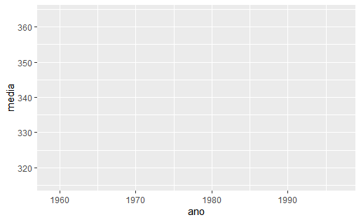

```r
co2_tidy %>%
  group_by(ano) %>%
  summarise(media = round(mean(ppm), 2)) %>%
  ggplot() +
    aes( x = ano, y = media )
```

#### 6º Camada *geom_point* (geometria)

- Camada da geometria dos dados.

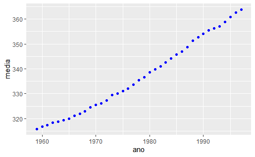

```r
co2_tidy %>%
  group_by(ano) %>%
  summarise(media = round(mean(ppm), 2)) %>%
  ggplot() +
    aes( x = ano, y = media ) +
    geom_point( color = "blue")
```

#### 7º Camada *labs* (titulo)

- Acrescentando o titulo ao gráfico.

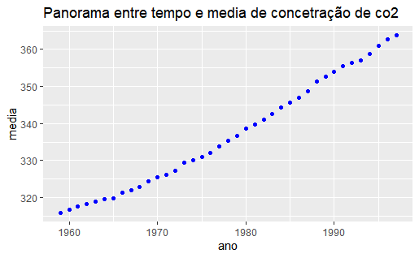

```r
co2_tidy %>%
  group_by(ano) %>%
  summarise(media = round(mean(ppm), 2)) %>%
  ggplot() +
    aes( x = ano, y = media ) +
    geom_point( color = "blue") +
  labs(
    title = "Panorama entre tempo e media de concetração de co2",
  )
```

### Resposta: *O gráfico de pontos está monstrando que: medida quer os anos passa a media da concetração de co2 continua aumentando.*

### 2. Gráfico de Linhas:

#### 1º Camada *Dataset* (co2_tidy)

- carregando o conjunto do dataset co2_tidy

```r
co2_tidy
```

| ano | mes | ppm |
| --- | --- | --- |
| 1959 | jan | 315.42 |
| 1959 | fev | 316.31 |
| 1959 | mar | 316.50 |
| 1959 | abr | 317.56 |
| 1959 | mai | 318.13 |
| 1959 | jun | 318.00 |
| 1959 | jul | 316.39 |
| 1959 | ago | 314.65 |
| 1959 | set | 313.68 |
| 1959 | out | 313.18 |

[output cut: 458 more lines]

#### 2º Camada *group_by* ( agrupamento de linha)

- Agrupando os dados da coluna ano

```r
co2_tidy %>%
  group_by(ano)
```

| ano | mes | ppm |
| --- | --- | --- |
| 1959 | jan | 315.42 |
| 1959 | fev | 316.31 |
| 1959 | mar | 316.50 |
| 1959 | abr | 317.56 |
| 1959 | mai | 318.13 |
| 1959 | jun | 318.00 |
| 1959 | jul | 316.39 |
| 1959 | ago | 314.65 |
| 1959 | set | 313.68 |
| 1959 | out | 313.18 |

[output cut: 458 more lines]

#### 3º Camada *summarise* (resumir)

```r
co2_tidy %>%
  group_by(ano) %>%
  summarise(
    media = round(sd(ppm), 1)
  )
```

| ano | media |
| --- | --- |
| 1959 | 1.6 |
| 1960 | 2.0 |
| 1961 | 1.8 |
| 1962 | 1.8 |
| 1963 | 2.0 |
| 1964 | 1.9 |
| 1965 | 1.7 |
| 1966 | 2.0 |
| 1967 | 1.8 |
| 1968 | 1.8 |

[output cut: 29 more lines]

#### 4º Camada *ggplot* (co2_tidy)

- Carregando o conjunto de dados;
- Carregando a camada estética geral.

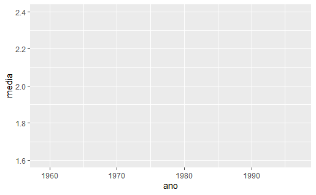

```r
co2_tidy %>%
  group_by(ano) %>%
  summarise(
    media = round(sd(ppm), 1)
  ) %>%
  ggplot(aes(x = ano, y = media, group = 1))
```

#### 5º Camada *geom_line* (geometria)

- Camada da geometria dos dados.

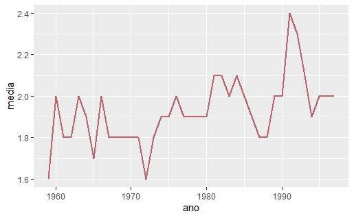

```r
co2_tidy %>%
  group_by(ano) %>%
  summarise(
    media = round(sd(ppm), 1)
  ) %>%
  ggplot(aes(x = ano, y = media, group = 1)) +
  geom_line(color = "#BF616A", size = 1)
```

#### 6º Camada *labs* (titulo, rotulo)

- Acrescentando o titulo e o rotulo ao gráfico.

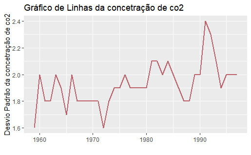

```r
co2_tidy %>%
  group_by(ano) %>%
  summarise(
    media = round(sd(ppm), 1)
  ) %>%
  ggplot(aes(x = ano, y = media, group = 1)) +
  geom_line(color = "#BF616A", size = 1) +
  labs(
    title = "Gráfico de Linhas da concetração de co2",
    x = "",
    y = "Desvio Padrão da concetração de co2"
  )
```

#### 7º Camada *theme_minimal* (tema)

- Colocando uma tema adequado aos aspectos gráficos.

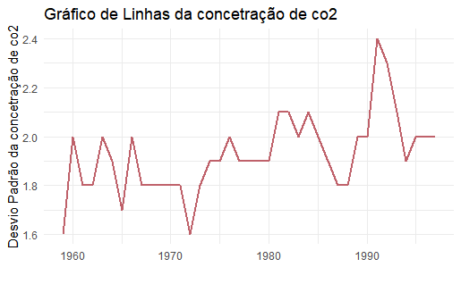

```r
co2_tidy %>%
  group_by(ano) %>%
  summarise(
    media = round(sd(ppm), 1)
  ) %>%
  ggplot(aes(x = ano, y = media, group = 1)) +
  geom_line(color = "#BF616A", size = 1) +
  labs(
    title = "Gráfico de Linhas da concetração de co2",
    x = "",
    y = "Desvio Padrão da concetração de co2"
  ) +
  theme_minimal()
```

### Resposta: *Como podemos ver no gráfico de pontos a medida que o tempo passa a concetração de co2 aumenta, já no gráfico de linha, a medida que o tempo passa, o desvio padão monstra quanto a média da concetração de co2 está distante da própria média.*

### 3. Gráficos de colunas ou barras:

#### 1º Camada *Dataset* (notas_tidy)

- carregando o conjunto do dataset notas_tidy.

```r
notas_tidy
```

| Curso | ano | ppm |
| --- | --- | --- |
| Qui | X2010 | 2.9 |
| Qui | X2011 | 6.8 |
| Qui | X2012 | 6.2 |
| Qui | X2013 | 4.1 |
| Qui | X2014 | 5.6 |
| Qui | X2015 | 4.0 |
| Qui | X2016 | 6.0 |
| Qui | X2017 | 7.4 |
| Qui | X2018 | 6.0 |
| Qui | X2019 | 4.1 |

[output cut: 210 more lines]

#### 2º Camada *count* (contagem)

- Fazendo a contagem dos diferentes dados.

```r
notas_tidy %>%
  count(Curso)
```

| Curso | n |
| --- | --- |
| Mat | 110 |
| Qui | 110 |

#### 3º Camada *ggplot* (notas_tidy)

- Carregando o conjunto de dados;
- Carregando a camada estética geral.

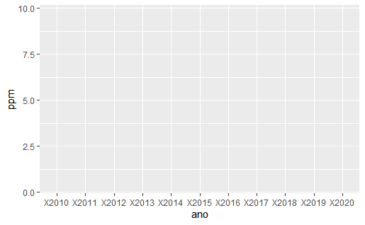

```r
notas_tidy %>%
  count(ano, ppm) %>%
  ggplot(aes(x = ano, y = ppm , color = ppm))
```

#### 4º Camada *geom_col* (geometria)

- Camada da geometria dos dados.

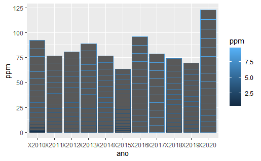

```r
notas_tidy %>%
  count(ano, ppm) %>%
  ggplot(aes(x = ano, y = ppm , color = ppm)) +
  geom_col()
```

### 4. Histograma:

#### 1º Camada *Dataset* (notas_tidy)

- carregando o conjunto do dataset notas_tidy.

```r
notas_tidy
```

| Curso | ano | ppm |
| --- | --- | --- |
| Qui | X2010 | 2.9 |
| Qui | X2011 | 6.8 |
| Qui | X2012 | 6.2 |
| Qui | X2013 | 4.1 |
| Qui | X2014 | 5.6 |
| Qui | X2015 | 4.0 |
| Qui | X2016 | 6.0 |
| Qui | X2017 | 7.4 |
| Qui | X2018 | 6.0 |
| Qui | X2019 | 4.1 |

[output cut: 210 more lines]

#### 2º Camada *ggplot* (notas_tidy)

- Carregando o conjunto de dados.

```r
notas_tidy %>%
  ggplot()
```

#### 3º Camada *aes* (estética)

- Carregando a camada estética geral.

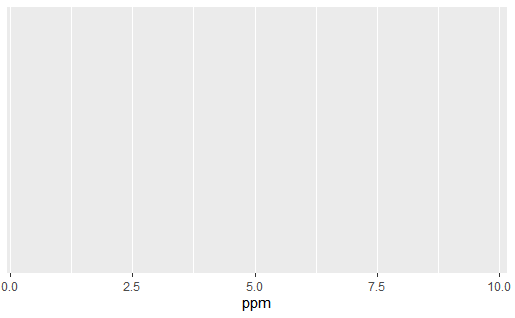

```r
notas_tidy %>%
  ggplot() +
  aes(x = ppm)
```

#### 4º Camada *geom_histogram* (geometria)

- Camada da geometria dos dados.

[output not shown]

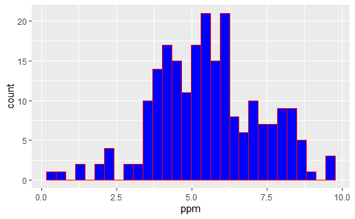

```r
notas_tidy %>%
  ggplot() +
  aes(x = ppm) +
  geom_histogram(fill = "blue", color = "red")
```

#### 5º Camada *labs* (titulo, rotulo)

- Acrescentando o titulo e o rotulo ao gráfico.

[output not shown]

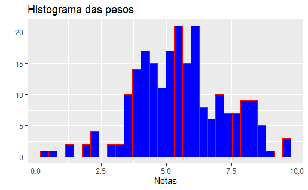

```r
notas_tidy %>%
  ggplot() +
  aes(x = ppm) +
  geom_histogram(fill = "blue", color = "red") +
  labs(
    title = "Histograma das pesos",
    x = "Notas",
    y = ""
  )
```

#### 6º Camada *theme_minimal* (tema)

- Colocando uma tema adequado aos aspectos gráficos.

[output not shown]

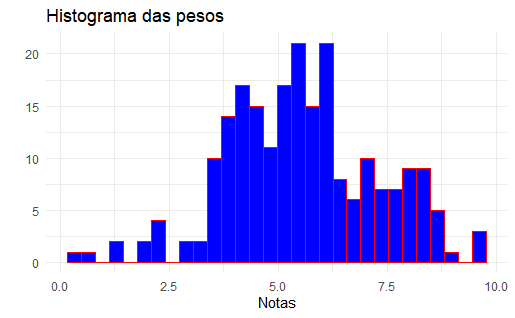

```r
notas_tidy %>%
  ggplot() +
  aes(x = ppm) +
  geom_histogram(fill = "blue", color = "red") +
  labs(
    title = "Histograma das pesos",
    x = "Notas",
    y = ""
  ) +
  theme_minimal()
```

### Resposta:*O histograma acima representa as média das notas das duas disciplinas juntas.*

### 5. Gráficos de densidade

#### 1º Camada *Dataset* (notas_tidy)

- carregando o conjunto do dataset notas_tidy.

```r
notas_tidy
```

| Curso | ano | ppm |
| --- | --- | --- |
| Qui | X2010 | 2.9 |
| Qui | X2011 | 6.8 |
| Qui | X2012 | 6.2 |
| Qui | X2013 | 4.1 |
| Qui | X2014 | 5.6 |
| Qui | X2015 | 4.0 |
| Qui | X2016 | 6.0 |
| Qui | X2017 | 7.4 |
| Qui | X2018 | 6.0 |
| Qui | X2019 | 4.1 |

[output cut: 210 more lines]

#### 2º Camada *ggplot* (notas_tidy)

- Carregando o conjunto de dados.

```r
notas_tidy %>%
  ggplot()
```

#### 3º Camada *aes* (estética)

- Carregando a camada estética geral.

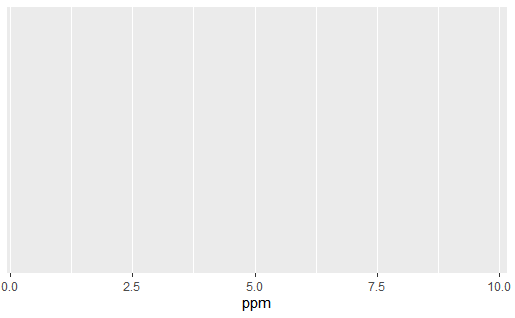

```r
notas_tidy %>%
  ggplot() +
  aes(x = ppm)
```

#### 4º Camada *geom_density* (geometria)

- Camada da geometria dos dados.

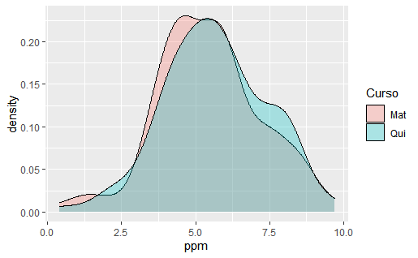

```r
notas_tidy %>%
  ggplot() +
  aes(x = ppm) +
  geom_density(aes(fill = Curso), alpha = 0.3)
```

#### 5º Camada *scale_fill_viridis_d (escala de cores)

- Carregando um conjunto de cores para ajudar na visualização de pessoas com dificuldade de visão ou daltonismo.

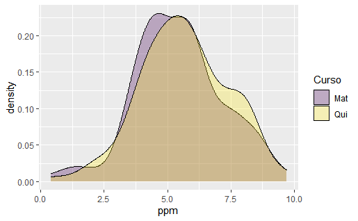

```r
notas_tidy %>%
  ggplot() +
  aes(x = ppm) +
  geom_density(aes(fill = Curso), alpha = 0.3) +
  scale_fill_viridis_d()
```

### Resposta:*O gráfico de densidade acima, está comparando as médias dos dois cursos durante todos os anos.*

### 6. Boxplot:

#### 1º Camada *Dataset* (nota_tidy)

- carregando o conjunto do dataset nota_tidy.

```r
notas_tidy
```

| Curso | ano | ppm |
| --- | --- | --- |
| Qui | X2010 | 2.9 |
| Qui | X2011 | 6.8 |
| Qui | X2012 | 6.2 |
| Qui | X2013 | 4.1 |
| Qui | X2014 | 5.6 |
| Qui | X2015 | 4.0 |
| Qui | X2016 | 6.0 |
| Qui | X2017 | 7.4 |
| Qui | X2018 | 6.0 |
| Qui | X2019 | 4.1 |

[output cut: 210 more lines]

#### 2º Camada *ggplot* (notas_tidy)

- Carregando o conjunto de dados.

```r
notas_tidy %>%
  ggplot()
```

#### 3º Camada *aes* (estética)

- Carregando a camada estética geral.

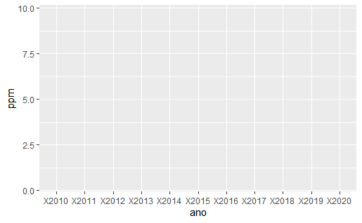

```r
notas_tidy %>%
  ggplot() +
  aes(x = ano, y= ppm)
```

#### 4º Camada *geom_boxplot* (geometria)

- Camada da geometria dos dados.

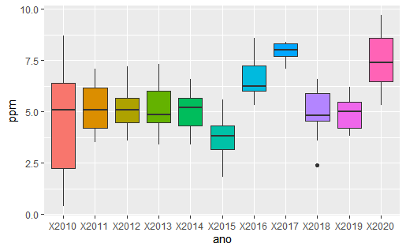

```r
notas_tidy %>%
  ggplot() +
  aes(x = ano, y= ppm) +
  geom_boxplot(aes(fill = ano), show.legend = FALSE)
```

#### 5º Camada *scale_fill_viridis_d*(escala de cores)

- Carregando um conjunto de cores para ajudar na visualização de pessoas com dificuldade de visão ou daltonismo.

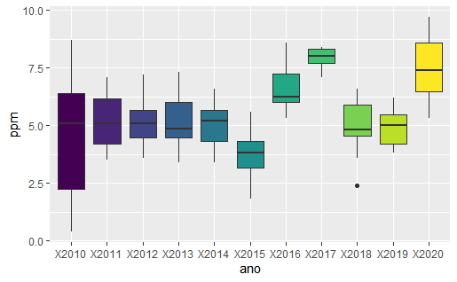

```r
notas_tidy %>%
  ggplot() +
  aes(x = ano, y= ppm) +
  geom_boxplot(aes(fill = ano), show.legend = FALSE) +
  scale_fill_viridis_d()
```

### Resposta: *O boxplot representa as notas dos cursos ao se passa dos anos.*